# P2

Jasmin Mousavi

11/18/2019

< Back to Portfolio

## **Gun Violence in the USA: Simple Modeling, Predicting, & Planning**

Based upon our initial discovery in part one, I would like to investigate trends regarding the number of incidents within each state.

Some of the questions we were left with revolved around potential political and social influences. Other questions revolve around the claims that organizations are making as to why gun violence is so high in the USA.

In order to get better insight to these imporant questions, we must first make a simple model to determine existing trends that occur within our data.

In this section, we will gather some new data regarding guns per capita, number of guns registered, and the population. Then we will use the population to determine the number of incidents per capita. With the new data we gathered and created, we will create a simple model to predict the number of incidents per capita.

Our simple model will provide us with better insight on what we need to investigate further, and perhaps bring to light some unexpected trends that exist within our data set.

## 1. Gather Data from part 1

- We want to gather our tidy tables and work we did with our intial gun violence data set

```r
install.packages("knitr", repos="http://cran.us.r-project.org")  #gather data
library(knitr)
purl("P1.Rmd", output = "part1.r")
```

```
##
##
## processing file: P1.Rmd
```

```
## output file: part1.r
```

```r
source("part1.r") #load the data from part 1
```

[figure not shown]

> Looking back at our tables

### Participant_Info

```r
Participant_Info
```

```
## # A tibble: 594,719 x 5
##    incident_id participant_name participant_age participant_age…
##    <fct>       <chr>                      <dbl> <fct>
##  1 461105      Julian Sims                   20 Adult 18+
##  2 460726      Bernard Gillis                20 Adult 18+
##  3 478855      Damien Bell                   25 Adult 18+
##  4 478855      Desmen Noble                  31 Adult 18+
##  5 478855      Herman Seagers                33 Adult 18+
##  6 478855      Ladd Tate Sr                  34 Adult 18+
##  7 478855      Tallis Moore                  33 Adult 18+
##  8 478925      Stacie Philbrook              29 Adult 18+
##  9 478925      Christopher Rat…              33 Adult 18+
## 10 478925      Anthony Ticali                56 Adult 18+
## # … with 594,709 more rows, and 1 more variable: participant_gender <fct>
```

### Participante_Incident_Info

```r
Participant_Incident_Info
```

```
## # A tibble: 235,459 x 4
##    incident_id participant_name     participant_status          participant_type
##    <fct>       <chr>                <fct>                       <fct>
##  1 461105      Julian Sims          Arrested                    Victim
##  2 460726      Bernard Gillis       Killed                      Victim
##  3 478855      Damien Bell          Injured, Unharmed, Arrested Subject-Suspect
##  4 478855      Desmen Noble         Unharmed, Arrested          Subject-Suspect
##  5 478855      Herman Seagers       Killed                      Victim
##  6 478855      Ladd Tate Sr         Injured                     Victim
##  7 478855      Tallis Moore         Injured                     Victim
##  8 478925      Stacie Philbrook     Killed                      Victim
##  9 478925      Christopher Ratliffe Killed                      Victim
## 10 478925      Anthony Ticali       Killed                      Victim
## # … with 235,449 more rows
```

### Gun_Info

```r
Gun_Info
```

```
## # A tibble: 130,191 x 4
##    incident_id participant_name            gun_stolen gun_type
##    <fct>       <chr>                       <fct>      <fct>
##  1 478855      Damien Bell                 Unknown    Unknown
##  2 478855      Desmen Noble                Unknown    Unknown
##  3 478959      Danielle Imani Jameison     Unknown    Handgun
##  4 478959      Maurice Eugene Edmonds, Sr. Unknown    Handgun
##  5 479363      Greg Griego                 Unknown    22 LR
##  6 479363      Sara Griego                 Unknown    223 Rem [AR-15]
##  7 491674      Demetrius Davis             Unknown    Unknown
##  8 479413      Terry Robinson Jr.          Unknown    Unknown
##  9 479561      Ofc.                        Unknown    Shotgun
## 10 479580      Teng Yang                   Unknown    9mm
## # … with 130,181 more rows
```

### Incident_Stats

```r
Incident_Stats$date <- as.POSIXct(Incident_Stats$date) #fixes posixlt
Incident_Stats
```

```
## # A tibble: 239,677 x 9
##    incident_id date                state city_or_county latitude longitude
##    <chr>       <dttm>              <fct> <fct>             <dbl>     <dbl>
##  1 461105      2013-01-01 00:00:00 Penn… Mckeesport         40.3     -79.9
##  2 460726      2013-01-01 00:00:00 Cali… Hawthorne          33.9    -118.
##  3 478855      2013-01-01 00:00:00 Ohio  Lorain             41.4     -82.1
##  4 478925      2013-01-05 00:00:00 Colo… Aurora             39.7    -105.
##  5 478959      2013-01-07 00:00:00 Nort… Greensboro         36.1     -80.0
##  6 478948      2013-01-07 00:00:00 Okla… Tulsa              36.2     -96.0
##  7 479363      2013-01-19 00:00:00 New … Albuquerque        35.0    -107.
##  8 479374      2013-01-21 00:00:00 Loui… New Orleans        29.9     -90.1
##  9 479389      2013-01-21 00:00:00 Cali… Brentwood          38.0    -122.
## 10 492151      2013-01-23 00:00:00 Mary… Baltimore          39.3     -76.6
## # … with 239,667 more rows, and 3 more variables: n_killed <dbl>,
## #   n_guns_involved <dbl>, n_injured <dbl>
```

### Incident_Government_Info

```r
Incident_Government_Info
```

```
## # A tibble: 239,677 x 4
##    incident_id state_house_district state_senate_district congressional_district
##    <chr>       <fct>                <fct>                 <fct>
##  1 461105      <NA>                 <NA>                  14
##  2 460726      62                   35                    43
##  3 478855      56                   13                    9
##  4 478925      40                   28                    6
##  5 478959      62                   27                    6
##  6 478948      72                   11                    1
##  7 479363      10                   14                    1
##  8 479374      93                   5                     2
##  9 479389      11                   7                     9
## 10 492151      <NA>                 44                    7
## # … with 239,667 more rows
```

### Incident_Characteristics

```r
Incident_Characteristics
```

```
## # A tibble: 576,861 x 2
##    incident_id incident_characteristics
##    <fct>       <fct>
##  1 461105      Shot - Wounded/Injured
##  2 461105      Mass Shooting (4+ victims injured or killed excluding the subjec…
##  3 461105      Possession (gun(s) found during commission of other crimes)
##  4 461105      Possession of gun by felon or prohibited person
##  5 460726      Shot - Wounded/Injured
##  6 460726      Shot - Dead (murder, accidental, suicide)
##  7 460726      Mass Shooting (4+ victims injured or killed excluding the subjec…
##  8 460726      Gang involvement
##  9 478855      Shot - Wounded/Injured
## 10 478855      Shot - Dead (murder, accidental, suicide)
## # … with 576,851 more rows
```

## 2. Gathering New Data

- Let’s gather data regarding gun ownership throughout the USA
  - source: https://www.thoughtco.com/gun-owners-percentage-of-state-populations-3325153
- Potential issues with the source
  - data gathered from survey done by Pew Research Center
  - going to have to trust the integrity of Pew Research Center, and how they conducted the survey
- Caveats with the data
  - data is only for the year of 2017
  - the year restriction will limit the scope of which we can make predictions an analyze

```r
library(rvest)     #web scrapping
library(tidyr)     #web scrapping
library(stringr)   #web scrapping

url<- "https://www.thoughtco.com/gun-owners-percentage-of-state-populations-3325153"

webpage <- read_html(url) #read in the html from the url

#use table headers as column names
col_name<- webpage %>%
  html_nodes("th") %>%
  html_text()

#save data inside table
mydata <- webpage %>%
  html_nodes("td") %>%
  html_text()

#convert scraped data to data frame
Guns_Per_Capita <- data.frame(matrix(mydata, ncol=4, byrow=TRUE))

Guns_Per_Capita <- Guns_Per_Capita[-1, ]

#rename columns
colnames(Guns_Per_Capita)[colnames(Guns_Per_Capita)=="X1"] <- "rank"
colnames(Guns_Per_Capita)[colnames(Guns_Per_Capita)=="X2"] <- "state"
colnames(Guns_Per_Capita)[colnames(Guns_Per_Capita)=="X3"] <- "num_of_guns_per_capita"
colnames(Guns_Per_Capita)[colnames(Guns_Per_Capita)=="X4"] <- "num_of_guns_registered"

Guns_Per_Capita <- as_tibble(Guns_Per_Capita)

#clean & tidy data
Guns_Per_Capita$num_of_guns_registered <- sub(",", "", Guns_Per_Capita$num_of_guns_registered)
Guns_Per_Capita$num_of_guns_registered <- as.numeric(Guns_Per_Capita$num_of_guns_registered)
Guns_Per_Capita$num_of_guns_per_capita <- as.character(Guns_Per_Capita$num_of_guns_per_capita)
options(digits = 5)
Guns_Per_Capita$num_of_guns_per_capita <- as.numeric(Guns_Per_Capita$num_of_guns_per_capita)
Guns_Per_Capita$state <- sub("Washington D.C.", "Washington", Guns_Per_Capita$state)

Guns_Per_Capita
```

```
## # A tibble: 51 x 4
##    rank  state         num_of_guns_per_capita num_of_guns_registered
##    <fct> <chr>                          <dbl>                  <dbl>
##  1 1     Wyoming                        229.                  132806
##  2 2     Washington                      68.0                  47228
##  3 3     New Hampshire                   46.8                  64135
##  4 4     New Mexico                      46.7                  97580
##  5 5     Virginia                        36.3                 307822
##  6 6     Alabama                         33.2                 161641
##  7 7     Idaho                           28.9                  49566
##  8 8     Arkansas                        26.6                  79841
##  9 9     Nevada                          25.6                  76888
## 10 10    Arizona                         25.6                 179738
## # … with 41 more rows
```

Now, let’s plot the data to get a better visualization

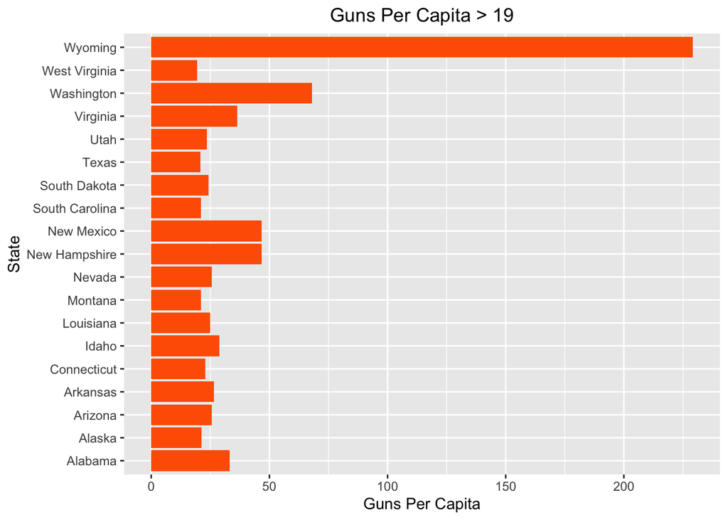

```r
Guns_Per_Capita_Subset <- Guns_Per_Capita %>% filter(num_of_guns_per_capita > 19) #Going to limit the guns per capita for those greater then 19

#Plot the data
ggplot(Guns_Per_Capita_Subset , aes(x=state, y=num_of_guns_per_capita)) +
  geom_bar(stat="identity", fill="#FE6100") +
  labs(x="State", y="Guns Per Capita")+
  ggtitle("Guns Per Capita > 19")+
  coord_flip()+
  theme(plot.title = element_text(hjust=0.5))
```

- Since the data we gathered describes guns per capita, let’s gather population data in 2017 to make capita calculations to predict on
- Population data in 2017
  - souce: https://www.enchantedlearning.com/usa/states/population.shtml
- Potential issues with the source
  - states it gets the data from US Census Bureau
  - have to trust it got the data from correctly
  - have to trust the US Census Bureau gathered data correctly

```r
url<- "https://www.enchantedlearning.com/usa/states/population.shtml"

webpage <- read_html(url) #read in the html

#use table headers as column names
col_name<- webpage %>%
  html_nodes("th") %>%
  html_text()

#save data inside table
mydata <- webpage %>%
  html_nodes("td") %>%
  html_text()

#convert scraped data to data frame
Population_2017 <- data.frame(matrix(mydata, ncol=2, byrow=TRUE))

Population_2017 <- Population_2017[-1, ]

#rename columns
colnames(Population_2017)[colnames(Population_2017)=="X1"] <- "state"
colnames(Population_2017)[colnames(Population_2017)=="X2"] <- "population"


Population_2017 <- as_tibble(Population_2017)

#clean & tidy data
Population_2017$state <- sub("\\d*\\. ", "", Population_2017$state)
Population_2017$population <- sub(",", "", Population_2017$population)
Population_2017$population <- sub(",", "", Population_2017$population)
Population_2017$population <- as.numeric(Population_2017$population)
Population_2017$state <- as.character(Population_2017$state)

Population_2017
```

```
## # A tibble: 51 x 2
##    state          population
##    <chr>               <dbl>
##  1 California       39536653
##  2 Texas            28304596
##  3 Florida          20984400
##  4 New York         19849399
##  5 Pennsylvania     12805537
##  6 Illinois         12802023
##  7 Ohio             11658609
##  8 Georgia          10429379
##  9 North Carolina   10273419
## 10 Michigan          9962311
## # … with 41 more rows
```

- Now, let’s plot the data to get a better visualization

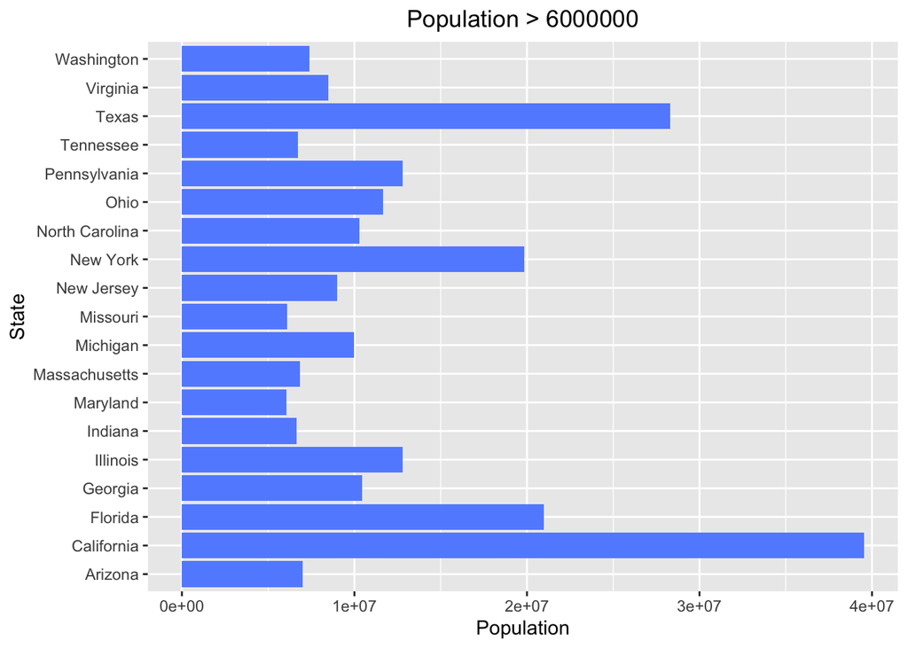

```r
Population_2017_Subset <- Population_2017 %>% filter(population > 6000000) #Going to limit the guns per capita for those greater then 6000000

ggplot(Population_2017_Subset , aes(x=state, y=population)) +
  geom_bar(stat="identity", fill="#648FFF") +
  labs(x="State", y="Population")+
  ggtitle("Population > 6000000") +
  coord_flip()+
  theme(plot.title = element_text(hjust=0.5))
```

- Now we can join our new tables with data from our old table

```r
# Join our incident table with our guns per capita table, for only 2017 data
State_Info <- Incident_Stats %>%
                    subset(format(as.Date(date),"%Y")==2017) %>%
                    left_join(Guns_Per_Capita, by="state") %>%
                    select(state,num_of_guns_per_capita,num_of_guns_registered,n_injured,n_killed,n_guns_involved)
# Now join the talbe we just created with our population table
State_Info <- State_Info %>%
                    left_join(Population_2017, by="state") %>%
                    select(num_of_guns_per_capita,num_of_guns_registered,n_injured,n_killed,n_guns_involved,population,state)

State_Info$state <- as.character(State_Info$state)

#create incidents per capita column by calculating number of incidents and dividing it by the population
State_Info$num_incidents <- as.numeric(ave(State_Info$state, State_Info$state, FUN = length))
State_Info$num_incidents_per_capita <- State_Info$num_incidents/State_Info$population

State_Info
```

```
## # A tibble: 62,282 x 9
##    num_of_guns_per… num_of_guns_reg… n_injured n_killed n_guns_involved
##               <dbl>            <dbl>     <dbl>    <dbl>           <dbl>
##  1             14.8            99159         0        1               1
##  2             11.6            22234         0        0               1
##  3             11.6            22234         1        0               1
##  4             18.4           236377         1        0               1
##  5             46.7            97580         0        0               1
##  6             36.3           307822         1        0               1
##  7             46.7            97580         0        0               1
##  8             46.7            97580         0        0               1
##  9             14.9           173405         1        0               1
## 10             17.1           114019         0        0               1
## # … with 62,272 more rows, and 4 more variables: population <dbl>, state <chr>,
## #   num_incidents <dbl>, num_incidents_per_capita <dbl>
```

- Plot the data of our new table to get a better visualization

```r
library(reshape2) #used to melt data set
Grouped_State_Info <- as.tibble(na.omit(State_Info)) %>%
                      group_by(state, num_of_guns_per_capita, num_incidents_per_capita) %>%
                      summarise(total=sum(num_of_guns_per_capita, num_incidents_per_capita)) %>%
                      mutate("gun_percentage"=num_of_guns_per_capita/total,"incident_percentage"=num_incidents_per_capita/total) %>%
                      ungroup() %>%
                      select(state, gun_percentage, incident_percentage)
```

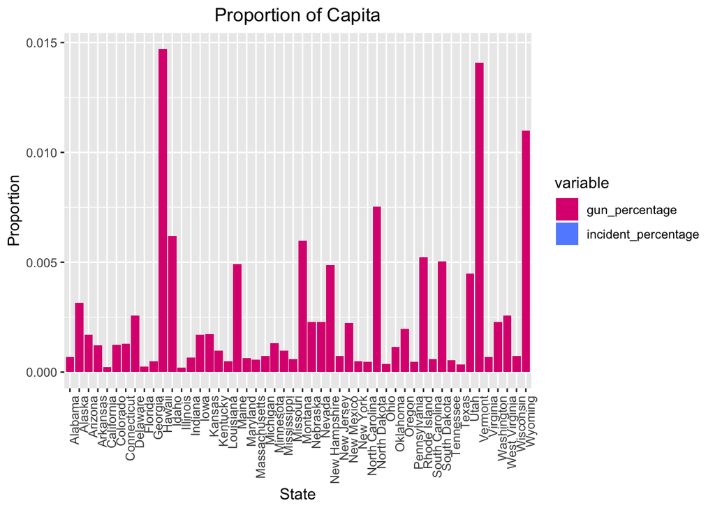

```r
Melted_State_Info <- melt(Grouped_State_Info, id.vars='state')
ggplot(Melted_State_Info, aes(state,value,fill=variable)) +
  geom_bar(stat="identity",position=position_stack()) +
  scale_fill_manual(values=c("#DC267F", "#648FFF")) +
  labs(x="State", y="Proportion")+
  ggtitle("Proportion of Capita")+
  theme(plot.title = element_text(hjust=0.5), axis.text.x = element_text(angle = 90, hjust = 1))
```

- As you can see, the incident percentage is magnatudes lower than the gun percentage where it isn’t visible on the graph

## 3. Modeling

- Let’s create a linear model in order to determine good predictors for incidents_per_capita
  - In order to calculate how well our model predicts, we should create a train and test set
  - We will build our model using the train set
  - After we are satisfied with our model, we can test our predictions on the test set
- Our first model will look at all values within our table in order to determine what are good predictors

```r
library(caret) #lm model
set.seed(385) #set the seed to get the same results
data_1 <- as_tibble(na.omit(State_Info)) #must remove na values when creating lm

#Partition into Train(75%) and Test(25%) sets
sample_1 <- createDataPartition(data_1$num_incidents_per_capita, p=0.75, list=FALSE)
train_1 <- data_1[sample_1, ]
test_1 <- data_1[-sample_1, ]

#create linear model
train_model_1 <- lm(formula= num_incidents_per_capita ~ num_of_guns_per_capita + num_of_guns_registered + num_incidents + n_injured + n_killed + n_guns_involved + population + state, data=train_1)

summary(train_model_1) #view our model
```

```
##
## Call:
## lm(formula = num_incidents_per_capita ~ num_of_guns_per_capita +
##     num_of_guns_registered + num_incidents + n_injured + n_killed +
##     n_guns_involved + population + state, data = train_1)
##
## Residuals:
##       Min        1Q    Median        3Q       Max
## -1.05e-14  0.00e+00  0.00e+00  0.00e+00  3.86e-15
##
## Coefficients: (3 not defined because of singularities)
##                         Estimate Std. Error   t value Pr(>|t|)
## (Intercept)             2.29e-04   7.90e-18  2.90e+13  < 2e-16 ***
## num_of_guns_per_capita -1.54e-07   4.08e-20 -3.78e+12  < 2e-16 ***
## num_of_guns_registered -1.92e-10   6.58e-23 -2.93e+12  < 2e-16 ***
## num_incidents           2.87e-07   2.23e-20  1.29e+13  < 2e-16 ***
## n_injured              -1.96e-18   4.89e-19 -4.01e+00  6.1e-05 ***
## n_killed                9.99e-19   6.86e-19  1.46e+00     0.15
## n_guns_involved        -1.37e-19   1.81e-19 -7.60e-01     0.45
## population             -6.42e-11   5.56e-24 -1.15e+13  < 2e-16 ***
## stateAlaska             1.62e-04   9.53e-18  1.70e+13  < 2e-16 ***
## stateArizona            1.75e-04   3.20e-17  5.47e+12  < 2e-16 ***
## stateArkansas           2.06e-05   4.12e-18  5.00e+12  < 2e-16 ***
## stateCalifornia         1.17e-03   1.35e-16  8.69e+12  < 2e-16 ***
## stateColorado           6.30e-05   1.42e-17  4.44e+12  < 2e-16 ***
## stateConnecticut        1.39e-05   4.62e-18  3.01e+12  < 2e-16 ***
## stateDelaware           1.27e-04   1.01e-17  1.26e+13  < 2e-16 ***
## stateFlorida            1.90e-04   4.23e-17  4.50e+12  < 2e-16 ***
## stateGeorgia            9.79e-05   2.06e-17  4.76e+12  < 2e-16 ***
## stateHawaii            -1.07e-04   1.13e-17 -9.51e+12  < 2e-16 ***
## stateIdaho             -5.68e-05   8.85e-18 -6.41e+12  < 2e-16 ***
## stateIllinois          -4.42e-04   4.06e-17 -1.09e+13  < 2e-16 ***
## stateIndiana            1.98e-05   6.64e-18  2.98e+12  < 2e-16 ***
## stateIowa              -2.37e-06   5.00e-18 -4.74e+11  < 2e-16 ***
## stateKansas             3.17e-06   4.95e-18  6.41e+11  < 2e-16 ***
## stateKentucky           1.05e-05   3.58e-18  2.94e+12  < 2e-16 ***
## stateLouisiana         -4.87e-05   1.63e-17 -2.99e+12  < 2e-16 ***
## stateMaine             -4.49e-05   7.76e-18 -5.79e+12  < 2e-16 ***
## stateMaryland          -1.09e-05   2.89e-18 -3.77e+12  < 2e-16 ***
## stateMassachusetts     -3.00e-05   5.57e-18 -5.39e+12  < 2e-16 ***
```

[output cut: 20 more lines]

```
## stateTennessee         -3.60e-05   4.81e-18 -7.49e+12  < 2e-16 ***
## stateTexas              9.79e-04   1.24e-16  7.89e+12  < 2e-16 ***
## stateUtah              -4.51e-06   1.35e-17 -3.33e+11  < 2e-16 ***
## stateVermont           -9.30e-05   1.12e-17 -8.29e+12  < 2e-16 ***
## stateVirginia           1.30e-04   2.82e-17  4.61e+12  < 2e-16 ***
## stateWashington        -2.49e-06   4.54e-18 -5.48e+11  < 2e-16 ***
## stateWest Virginia            NA         NA        NA       NA
## stateWisconsin                NA         NA        NA       NA
## stateWyoming                  NA         NA        NA       NA
## ---
## Signif. codes:  0 '***' 0.001 '**' 0.01 '*' 0.05 '.' 0.1 ' ' 1
##
## Residual standard error: 7.13e-17 on 45698 degrees of freedom
## Multiple R-squared:     1,   Adjusted R-squared:     1
## F-statistic: 1.48e+27 on 53 and 45698 DF,  p-value: <2e-16
```

- Here we can see that n_guns_involved and n_killed aren’t the best predictors (high p-value)
  - Let’s make a model without these values

```r
#must remove na values when creating lm
data_2 <- as_tibble(State_Info) %>%
  drop_na(num_of_guns_per_capita) %>%
  drop_na(num_of_guns_registered) %>%
  drop_na(num_incidents_per_capita) %>%
  drop_na(population) %>%
  drop_na(num_incidents) %>%
  drop_na(n_injured) %>%
  drop_na(state)

#Partition into Train(75%) and Test(25%) sets
sample_2 <- createDataPartition(data_2$num_incidents_per_capita, p=0.75, list=FALSE)
train_2 <- data_2[sample_2, ]
test_2 <- data_2[-sample_2, ]

#create linear model
train_model_2 <- lm(formula= num_incidents_per_capita ~ num_of_guns_per_capita + num_of_guns_registered + n_injured + num_incidents + population + state, data=train_2)

summary(train_model_2)
```

```
##
## Call:
## lm(formula = num_incidents_per_capita ~ num_of_guns_per_capita +
##     num_of_guns_registered + n_injured + num_incidents + population +
##     state, data = train_2)
##
## Residuals:
##       Min        1Q    Median        3Q       Max
## -9.22e-15  0.00e+00  0.00e+00  0.00e+00  1.39e-14
##
## Coefficients: (3 not defined because of singularities)
##                         Estimate Std. Error   t value Pr(>|t|)
## (Intercept)             2.29e-04   9.09e-18  2.52e+13   <2e-16 ***
## num_of_guns_per_capita -1.54e-07   4.78e-20 -3.23e+12   <2e-16 ***
## num_of_guns_registered -1.92e-10   7.75e-23 -2.49e+12   <2e-16 ***
## n_injured               7.73e-18   5.58e-19  1.38e+01   <2e-16 ***
## num_incidents           2.87e-07   2.63e-20  1.09e+13   <2e-16 ***
## population             -6.42e-11   6.53e-24 -9.82e+12   <2e-16 ***
## stateAlaska             1.62e-04   1.11e-17  1.46e+13   <2e-16 ***
## stateArizona            1.75e-04   3.76e-17  4.65e+12   <2e-16 ***
## stateArkansas           2.06e-05   4.87e-18  4.23e+12   <2e-16 ***
## stateCalifornia         1.17e-03   1.58e-16  7.41e+12   <2e-16 ***
## stateColorado           6.30e-05   1.67e-17  3.77e+12   <2e-16 ***
## stateConnecticut        1.39e-05   5.46e-18  2.55e+12   <2e-16 ***
## stateDelaware           1.27e-04   1.18e-17  1.08e+13   <2e-16 ***
## stateFlorida            1.90e-04   4.94e-17  3.85e+12   <2e-16 ***
## stateGeorgia            9.79e-05   2.41e-17  4.06e+12   <2e-16 ***
## stateHawaii            -1.07e-04   1.34e-17 -8.00e+12   <2e-16 ***
## stateIdaho             -5.68e-05   1.04e-17 -5.45e+12   <2e-16 ***
## stateIllinois          -4.42e-04   4.79e-17 -9.23e+12   <2e-16 ***
## stateIndiana            1.98e-05   7.80e-18  2.53e+12   <2e-16 ***
## stateIowa              -2.37e-06   5.85e-18 -4.04e+11   <2e-16 ***
## stateKansas             3.17e-06   5.81e-18  5.46e+11   <2e-16 ***
## stateKentucky           1.05e-05   4.24e-18  2.49e+12   <2e-16 ***
## stateLouisiana         -4.87e-05   1.92e-17 -2.54e+12   <2e-16 ***
## stateMaine             -4.49e-05   8.86e-18 -5.07e+12   <2e-16 ***
## stateMaryland          -1.09e-05   3.41e-18 -3.20e+12   <2e-16 ***
## stateMassachusetts     -3.00e-05   6.56e-18 -4.58e+12   <2e-16 ***
## stateMichigan           1.70e-04   2.87e-17  5.91e+12   <2e-16 ***
## stateMinnesota          6.43e-05   1.69e-17  3.80e+12   <2e-16 ***
```

[output cut: 18 more lines]

```
## stateTennessee         -3.60e-05   5.68e-18 -6.34e+12   <2e-16 ***
## stateTexas              9.79e-04   1.46e-16  6.72e+12   <2e-16 ***
## stateUtah              -4.51e-06   1.58e-17 -2.84e+11   <2e-16 ***
## stateVermont           -9.30e-05   1.36e-17 -6.84e+12   <2e-16 ***
## stateVirginia           1.30e-04   3.32e-17  3.92e+12   <2e-16 ***
## stateWashington        -2.49e-06   5.32e-18 -4.68e+11   <2e-16 ***
## stateWest Virginia            NA         NA        NA       NA
## stateWisconsin                NA         NA        NA       NA
## stateWyoming                  NA         NA        NA       NA
## ---
## Signif. codes:  0 '***' 0.001 '**' 0.01 '*' 0.05 '.' 0.1 ' ' 1
##
## Residual standard error: 8.45e-17 on 45805 degrees of freedom
## Multiple R-squared:     1,   Adjusted R-squared:     1
## F-statistic: 1.09e+27 on 51 and 45805 DF,  p-value: <2e-16
```

- Looking at the different states, there is much variability here
  - Depending on the state, it can be a positive or negative predictor for num_incidents_per_capita
  - This could be due to differences in gun laws or some other factor
  - Since this is so noisey, let’s take the state out of our model
  - Potentially, we can address this in the following investigation
- Create a model without state

```r
#must remove na values when creating lm
data_3 <- as_tibble(State_Info) %>%
  drop_na(num_of_guns_per_capita) %>%
  drop_na(num_of_guns_registered) %>%
  drop_na(num_incidents_per_capita) %>%
  drop_na(population) %>%
  drop_na(num_incidents) %>%
  drop_na(n_injured) %>%
  drop_na(state)

#Partition into Train(75%) and Test(25%) sets
sample_3 <- createDataPartition(data_3$num_incidents_per_capita, p=0.75, list=FALSE)
train_3 <- data_3[sample_3, ]
test_3 <- data_3[-sample_3, ]

#create linear model
train_model_3 <- lm(formula= num_incidents_per_capita ~ num_of_guns_per_capita + num_of_guns_registered + num_incidents + population + n_injured, data=train_3)

summary(train_model_3)#view our model
```

```
##
## Call:
## lm(formula = num_incidents_per_capita ~ num_of_guns_per_capita +
##     num_of_guns_registered + num_incidents + population + n_injured,
##     data = train_3)
##
## Residuals:
##       Min        1Q    Median        3Q       Max
## -1.52e-04 -3.08e-05 -6.97e-06  2.80e-05  2.06e-04
##
## Coefficients:
##                         Estimate Std. Error t value Pr(>|t|)
## (Intercept)             2.05e-04   6.24e-07  328.27  < 2e-16 ***
## num_of_guns_per_capita  2.36e-07   2.03e-08   11.60  < 2e-16 ***
## num_of_guns_registered -7.03e-11   2.97e-12  -23.70  < 2e-16 ***
## num_incidents           6.66e-08   2.41e-10  275.89  < 2e-16 ***
## population             -1.03e-11   4.71e-14 -218.42  < 2e-16 ***
## n_injured               1.49e-06   3.29e-07    4.54  5.6e-06 ***
## ---
## Signif. codes:  0 '***' 0.001 '**' 0.01 '*' 0.05 '.' 0.1 ' ' 1
##
## Residual standard error: 5.02e-05 on 45851 degrees of freedom
## Multiple R-squared:  0.71,   Adjusted R-squared:  0.71
## F-statistic: 2.25e+04 on 5 and 45851 DF,  p-value: <2e-16
```

- Here we have all very low p-values, making everything a good predictor of num_incidents_per_capita
- Our Predictors:
  - num_guns_per_capita: Here we can see that that as guns per capita increases, incidents per capita increases
  - num_of_guns_registered: Here we can see that as number of guns registered increases, incidents per capita decreases
  - num_incidents: Here we can see that as the number of incidents increases, the number of incidents per capita increases
  - population: Here we can see that as population increases, then incidents per capita decreases
  - n_injured: Here we can see as the number of injured increases, the incidents per capita increases
- Interpreting model results:
  - Positive predictors: nums_of_guns_per_capita, num_incidents, n_injured
  - Negative predictors: num_of_guns_registered, population
  - It is interesting to see that population and number of guns registered are negative predictors
  - One would assume that the larger the population, the more incidents there are. Similarly, the greater number of registered guns, the more incidents there are. However, there could be stricter gun laws in states with larger populations which could be the cause as to why these values are identified as negative predictors
- Now we can calculate predictions using our model and test set

```r
predictions_3 <- train_model_3 %>% predict(test_3)

#R2 is the sqare & root of the correlation (between 0[no correlation] and 1[perfect correlation])
#RMSE is the standard deviation of the predicted errors
#MAE mean absolute error of the distance between the predicted and actual value
errors_3 <- data.frame(R2 = R2(predictions_3, test_3$num_incidents_per_capita),
           RMSE = RMSE(predictions_3, test_3$num_incidents_per_capita),
           MAE = MAE(predictions_3, test_3$num_incidents_per_capita))

errors_3
```

```
##        R2       RMSE        MAE
## 1 0.71771 4.9556e-05 3.6767e-05
```

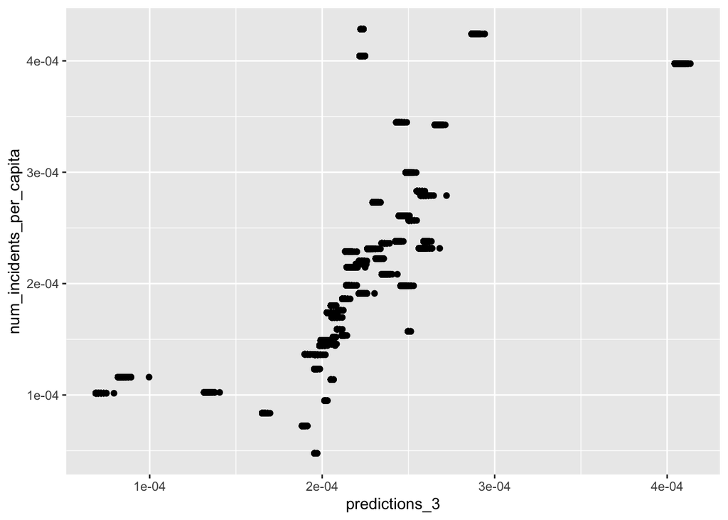

```r
ggplot(test_3, aes(x=predictions_3, y=num_incidents_per_capita), ) + geom_point()
```

- Here we can see that although our results are slightly noisey, the general trend seems to be positive

> What are the limitations to our model?
- Data sets are gathererd from different sources, and therefore conducted differently. This can lead to inconsistencies when making correlations or predictions
- New data added is only for 2017 data, so the modeling and predictions are acting as a proxy for the rest of the data
  - However our model is only making predictions for 2017
  - In order to truly make a prediction for the entire data set, we would have to gather guns per capita data data and population data from 2013 to 2018
- In order to understand the negative predictors in our final model, it would be necessary to gather more data in order to make sense of the existance of these trends

## 4. What should we investigate further?

- Due to the interesting results regarding the states while we were creating our model, we could potentially group together the states that were positive predictors and the states that were negative predictors
  - Perhaps grouping them will allow us to see futher trends
- Additionally, it would be interesting to see how many gun laws, differences in gun laws, or changes of gun laws (over the years):
  - Effect our model
  - Explain the negative predictors (population and number of guns registered) in our model
  - Explain why the state predictions were so noisey
- Investigating gun laws can potentially lead to answering some of the in depth questions that were asked in part one

Link to Part 3 of Portfolio >